# Electronic Cigarette and Youth

Shengjie Sun & Chen Chen

2019-04-30

# II. Description of the data source

We mainly collect row data from `Centers for Disease Control and Prevention` and the link is: https://www.cdc.gov/tobacco/data_statistics/surveys/nyts/data/index.html.

Data are available in SAS, Microsoft Access, and Microsoft Excel formats, as well as PDFs of the questionnaire, codebook, and methodology report.

The data reveals the smoking and tobacco usage among youth and collected by doing survey called `National Youth Tobacco Survey (NYTS)`. Data from 1999 and 2018 are available but we only choose those from 2011 to 2018 as the topics releated to electronic cigarette appear in these surveys as early as 2011. The data for a particular year, say 2018 looks like following:

|  | Q6 | Q7 | Q8 | Q9 | Q10 | Q11 |
| --- | --- | --- | --- | --- | --- | --- |
| 1 | 4 | 2 | 01 | 1 | 1 | 1 |
| 2 | 4 | 2 | 01 | 1 | 1 | 1 |
| 3 | 4 | 2 | 01 | 1 | 1 | 1 |
| 4 | 2 | 2 | 01 | 1 | 1 | 1 |
| 5 | 1 | 2 | 01 | 1 | 1 | 1 |
| 6 | 4 | 1 | 06 | 2 | 7 | 1 |
| 7 | 3 | 2 | 01 | 1 | 1 | 1 |
| 8 | 4 | 1 | 02 | 1 | 8 | 1 |
| 9 | 4 | 2 | 01 | 1 | 1 | 1 |
| 10 | 2 | 2 | 01 | 1 | 1 | 1 |

[output cut: 10 more lines]

The biggest problem for us is that the questionnaire are different from year to year and we need to go through every questions in each year and select the questions that:

1. related to electronic cigarettes,
2. appear at least four years,
3. high quality and can reveal some “truth”.

We divided all the questions related to e-cigarettes into indirectly related and directly related based on whether the words such as “e-cigaretted”, “vape”, etc appears in questions or just appears as an options/selections.

It is quite clear that the number of leaps from 2013 to 2014 and goes to peak in 2016. It’s may worth to mention that all survey questionnaire of 2017 and 2018 are the same.

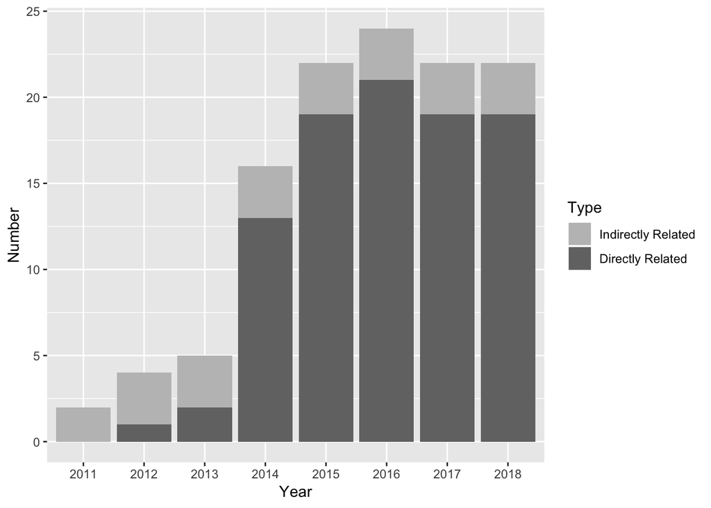

Before 2011, there is no question related to e-cigarettes/vapes, and during 2011, 2012 and 2013, e-cigarettes and vapes are just mentioned within questions. From 2014 to 2016, great attention was paid while the questions varies. Starting from 2017, the questions related to e-cigarettes keep same.

All the questions selected are post in another blog called `All National Youth Tobacco Survey Questions Related to Electronic Cigarette` feel free to check it.